# Apple Stock Data (Monthly 2016-2024)

Brianna Cirillo

### Libraries

```r
# Load necessary libraries
library(forecast)
library(tseries)
library(TSA)
library(tidyverse)
library(rugarch)
```

## AAPL Monthly Data 2016-2024

### Load & Inspect the Data

```r
# Load the data
aapl_monthly_data <- read.csv("~/Documents/GitHub/MA-641-Course-Project/AAPL_Monthly2016.csv")

# Convert the date column to Date type
aapl_monthly_data$Date <- as.Date(aapl_monthly_data$Date, format="%Y-%m-%d")

# Inspect the data
head(aapl_monthly_data)
```

|  | Date | Open | High | Low | Close | Adj.Close | Volume |
| --- | --- | --- | --- | --- | --- | --- | --- |
| 1 | 2016-01-01 | 25.6525 | 26.4625 | 23.0975 | 24.3350 | 22.09621 | 5087392000 |
| 2 | 2016-02-01 | 24.1175 | 24.7225 | 23.1475 | 24.1725 | 21.94866 | 3243450400 |
| 3 | 2016-03-01 | 24.4125 | 27.6050 | 24.3550 | 27.2475 | 24.87501 | 2984198400 |
| 4 | 2016-04-01 | 27.1950 | 28.0975 | 23.1275 | 23.4350 | 21.39447 | 3489534800 |
| 5 | 2016-05-01 | 23.4925 | 25.1825 | 22.3675 | 24.9650 | 22.79125 | 3602686000 |
| 6 | 2016-06-01 | 24.7550 | 25.4725 | 22.8750 | 23.9000 | 21.95182 | 3117990800 |

```r
summary(aapl_monthly_data)
```

```
      Date                 Open             High             Low             Close          Adj.Close
 Min.   :2016-01-01   Min.   : 23.49   Min.   : 24.72   Min.   : 22.37   Min.   : 23.43   Min.   : 21.39
 1st Qu.:2018-02-01   1st Qu.: 41.74   1st Qu.: 44.30   1st Qu.: 40.16   1st Qu.: 41.95   1st Qu.: 39.72
 Median :2020-03-01   Median : 71.56   Median : 81.06   Median : 64.09   Median : 73.45   Median : 71.54
 Mean   :2020-03-01   Mean   : 94.47   Mean   :101.04   Mean   : 88.97   Mean   : 95.93   Mean   : 93.98
 3rd Qu.:2022-04-01   3rd Qu.:148.99   3rd Qu.:157.50   3rd Qu.:138.27   3rd Qu.:149.80   3rd Qu.:147.50
 Max.   :2024-05-01   Max.   :196.24   Max.   :199.62   Max.   :187.45   Max.   :196.45   Max.   :195.41
     Volume
 Min.   :9.697e+08
 1st Qu.:1.676e+09
 Median :2.240e+09
 Mean   :2.320e+09
 3rd Qu.:2.801e+09
 Max.   :6.280e+09
```

### Create a Time Series Object

```r
# Create a time series object
aaplmonthly_ts <- ts(aapl_monthly_data$Close, start=c(2016, 01), end = c(2024, 05), frequency=12)
```

### Descripvtive Analysis

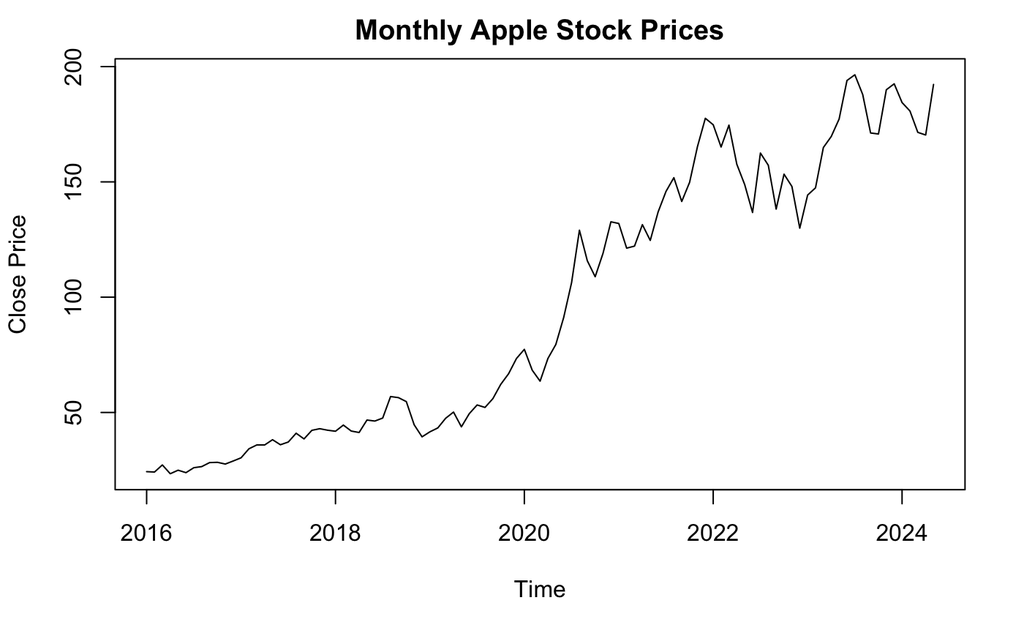

```r
# Descriptive Analysis
plot(aaplmonthly_ts, main="Monthly Apple Stock Prices", ylab="Close Price", xlab="Time")
```

```r
summary(aaplmonthly_ts)
```

```
   Min. 1st Qu.  Median    Mean 3rd Qu.    Max.
  23.43   41.95   73.45   95.93  149.80  196.45
```

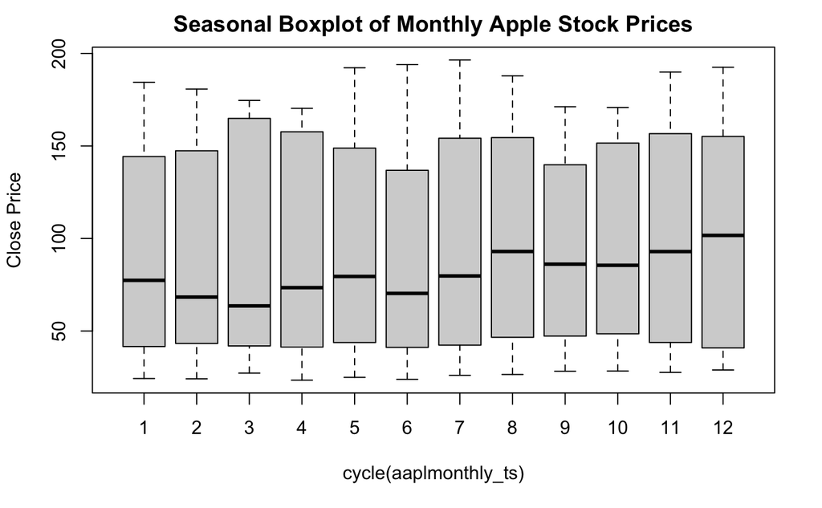

```r
boxplot(aaplmonthly_ts ~ cycle(aaplmonthly_ts), main="Seasonal Boxplot of Monthly Apple Stock Prices", ylab="Close Price")
```

Time Series Plot:

- There is a clear upward trend in Apple stock prices over the period. The prices show a substantial increase, particularly starting around 2019.
- There is visible volatility in the stock prices, with fluctuations becoming more pronounced in the later years.
- The increased volatility may imply higher risk for investors, as the stock prices have larger swings.

Summary:

- The mean and median values suggest that the central tendency of the stock prices is around 73 to 96.
- The range indicates that the stock price has varied significantly over the period.

### ACF, PACF, & EACF Plots

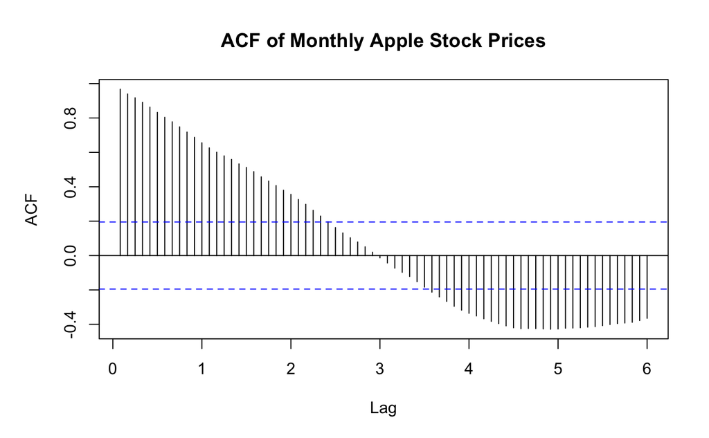

```r
# ACF and PACF Plots
par(mar=c(5, 5, 4, 2) + 0.1)
acf(aaplmonthly_ts, main="ACF of Monthly Apple Stock Prices", lag.max = 72)
```

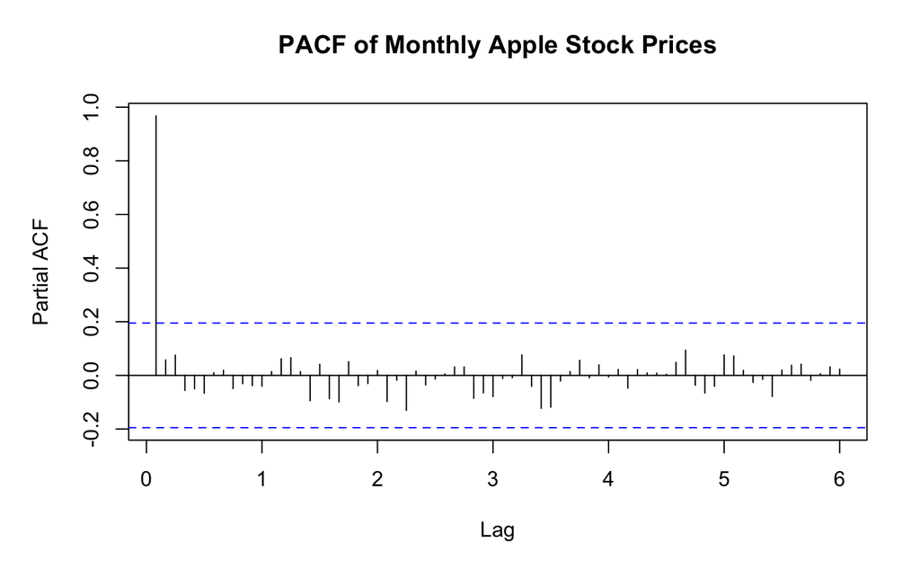

```r
pacf(aaplmonthly_ts, main="PACF of Monthly Apple Stock Prices", lag.max = 72)
```

```r
eacf(aaplmonthly_ts)
```

```
AR/MA
  0 1 2 3 4 5 6 7 8 9 10 11 12 13
0 x x x x x x x x x x x  x  x  x
1 o x o o o o o o o o o  o  o  o
2 x x o o o o o o x o o  o  o  o
3 o o o o o o o o o o o  o  o  o
4 x o o o o o o o o o o  o  o  o
5 o o o o o o o o o o o  o  o  o
6 o o o o o o o o o o o  o  o  o
7 o o o x o o o o o o o  o  o  o
```

ACF Plot:

- The gradual decay in the ACF indicates the presence of a trend component in the time series. The series is likely non-stationary.
- Significant autocorrelations suggest that the data is not random and past values can help predict future values.
- A high degree of positive autocorrelation at the first few lags implies momentum in the stock prices, which is common in financial time series.

PACF Plot:

- The sharp drop after the first lag in the PACF suggests that an AR(1) model may be appropriate for capturing the relationship in the data.
- The significant first lag indicates that the immediate past value has a strong influence on the current value, while the influence of values further in the past diminishes quickly.
- This pattern supports the use of a simple autoregressive model, as the complexity beyond the first lag does not add much explanatory power.

### ADF Test

```r
# Augmented Dickey-Fuller Test
adf_test <- adf.test(aaplmonthly_ts, alternative="stationary")
print(adf_test)
```

```
    Augmented Dickey-Fuller Test

data:  aaplmonthly_ts
Dickey-Fuller = -2.3411, Lag order = 4, p-value = 0.4353
alternative hypothesis: stationary
```

- Since the p-value is greater than 0.05, we fail to reject the null hypothesis that the time series has a unit root. This indicates that the series is non-stationary.
- The non-stationarity observed from the ADF test results implies that differencing the time series is necessary to achieve stationarity.

```r
# Differencing the series if it is not stationary
if (adf_test$p.value > 0.05) {
  ts_data_diff <- diff(aaplmonthly_ts, differences=1)
  adf_test_diff <- adf.test(ts_data_diff, alternative="stationary")
  print(adf_test_diff)

  # Update the time series data to the differenced series
  aaplmonthly_ts <- ts_data_diff
}
```

```
    Augmented Dickey-Fuller Test

data:  ts_data_diff
Dickey-Fuller = -5.0114, Lag order = 4, p-value = 0.01
alternative hypothesis: stationary
```

- Since the p-value is less than 0.05, we reject the null hypothesis that the time series has a unit root. This indicates that the differenced series is stationary.
- With the differenced series being stationary, it is now suitable for fitting ARIMA models.

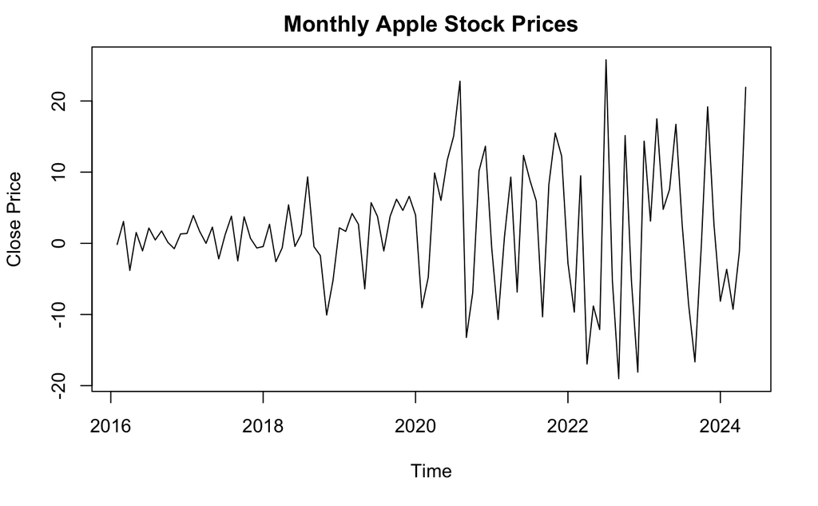

```r
# Time Series Plot after Differencing
plot(aaplmonthly_ts, main="Monthly Apple Stock Prices", ylab="Close Price", xlab="Time")
```

- We can see that after differencing the time-series appears to be stationary.

### Fit AR, MA, and ARMA Models

#### AR Model

```r
# Fit AR model
ar_model <- Arima(aaplmonthly_ts, order=c(2,0,0))
summary(ar_model)
```

```
Series: aaplmonthly_ts
ARIMA(2,0,0) with non-zero mean

Coefficients:
         ar1      ar2    mean
      0.0409  -0.2708  1.6476
s.e.  0.0988   0.0980  0.6883

sigma^2 = 73.24:  log likelihood = -355.13
AIC=718.27   AICc=718.69   BIC=728.69

Training set error measures:
                       ME     RMSE     MAE      MPE     MAPE      MASE         ACF1
Training set -0.000308276 8.428628 6.23919 507.0341 563.7521 0.7036177 -0.001614169
```

- The mean value of 1.6476 indicates the average level around which the time series fluctuates.
- The standard errors for the coefficients are relatively small, suggesting that the estimates are reasonably precise.
- While the error measures such as RMSE and MAE are low, indicating good prediction accuracy, the high MAPE value suggests potential issues with percentage errors possibly due to the inherent volatility in stock prices.

#### MA Model

```r
# Fit MA model
ma_model <- Arima(aaplmonthly_ts, order=c(0,0,2))
summary(ma_model)
```

```
Series: aaplmonthly_ts
ARIMA(0,0,2) with non-zero mean

Coefficients:
         ma1      ma2    mean
      0.0231  -0.2775  1.6525
s.e.  0.0979   0.0971  0.6327

sigma^2 = 73.16:  log likelihood = -355.09
AIC=718.17   AICc=718.59   BIC=728.59

Training set error measures:
                       ME     RMSE     MAE      MPE     MAPE      MASE      ACF1
Training set -0.006781185 8.424279 6.24754 520.9368 585.7699 0.7045594 0.0114845
```

#### ARMA Model

```r
# Fit ARMA model
arma_model1 <- Arima(aaplmonthly_ts, order=c(1,1,1))
summary(arma_model1)
```

```
Series: aaplmonthly_ts
ARIMA(1,1,1)

Coefficients:
         ar1      ma1
      0.0413  -1.0000
s.e.  0.1034   0.0308

sigma^2 = 78.94:  log likelihood = -357.98
AIC=721.96   AICc=722.21   BIC=729.74

Training set error measures:
                    ME     RMSE      MAE     MPE     MAPE      MASE          ACF1
Training set 0.5179315 8.750795 6.505048 433.929 441.6441 0.7335995 -0.0008596899
```

```r
# ARMA(2,1) Model
arma_model2 <- Arima(aaplmonthly_ts, order=c(2,1,1))
summary(arma_model2)
```

```
Series: aaplmonthly_ts
ARIMA(2,1,1)

Coefficients:
         ar1      ar2      ma1
      0.0486  -0.2632  -1.0000
s.e.  0.0996   0.0988   0.0377

sigma^2 = 74.02:  log likelihood = -354.58
AIC=717.16   AICc=717.59   BIC=727.54

Training set error measures:
                    ME     RMSE      MAE      MPE     MAPE      MASE        ACF1
Training set 0.6253754 8.429532 6.225648 78.44247 127.6236 0.7020905 -0.01202426
```

- The ARIMA(2,1,1) model introduces additional AR and MA components compared to simpler models, but the improvement in fit is minimal.
- The AIC and BIC values are slightly lower, and the standard errors for the AR(2) and MA(1) coefficients remain relatively high.
- Overall, the simpler AR(2) models might be preferred for their comparable fit and simplicity.

#### Model Comparison

```r
# Comparing Models using AIC and BIC
models <- list(ar_model, ma_model, arma_model1, arma_model2)
model_names <- c("AR", "MA", "ARIMA(1,1,1)", "ARIMA(2,1,1)")

aic_values <- sapply(models, AIC)
bic_values <- sapply(models, BIC)

comparison <- data.frame(Model=model_names, AIC=aic_values, BIC=bic_values)
print(comparison)
```

| Model | AIC | BIC |
| --- | --- | --- |
| AR | 718.2679 | 728.6886 |
| MA | 718.1726 | 728.5933 |
| ARIMA(1,1,1) | 721.9588 | 729.7442 |
| ARIMA(2,1,1) | 717.1604 | 727.5408 |

### Residual Analysis

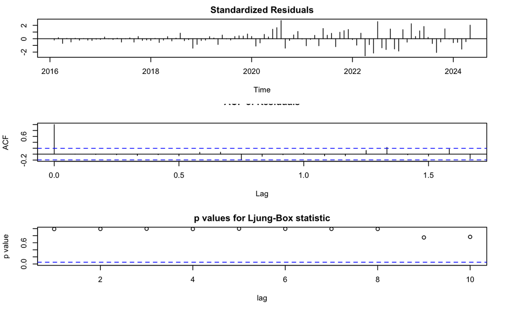

```r
# Enhanced residual analysis using tsdiag
# AR(2)
tsdiag(ar_model)
```

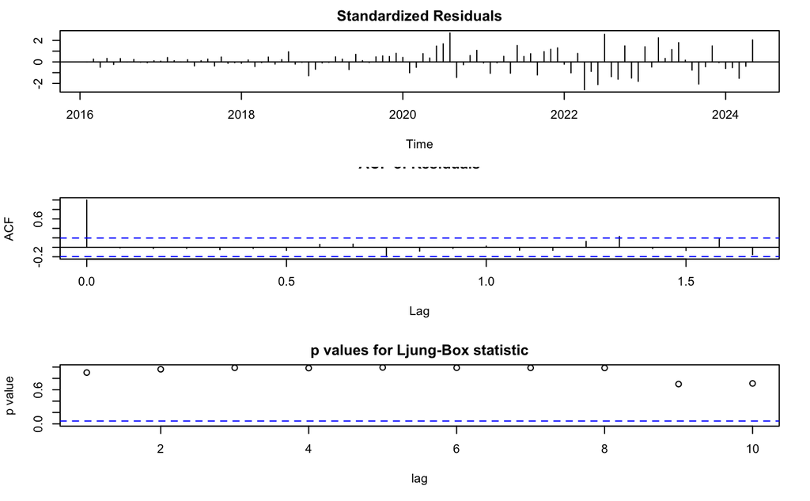

```r
# Enhanced residual analysis using tsdiag
# ARIMA(2,1,1)
tsdiag(arma_model2)
```

### Forecasting

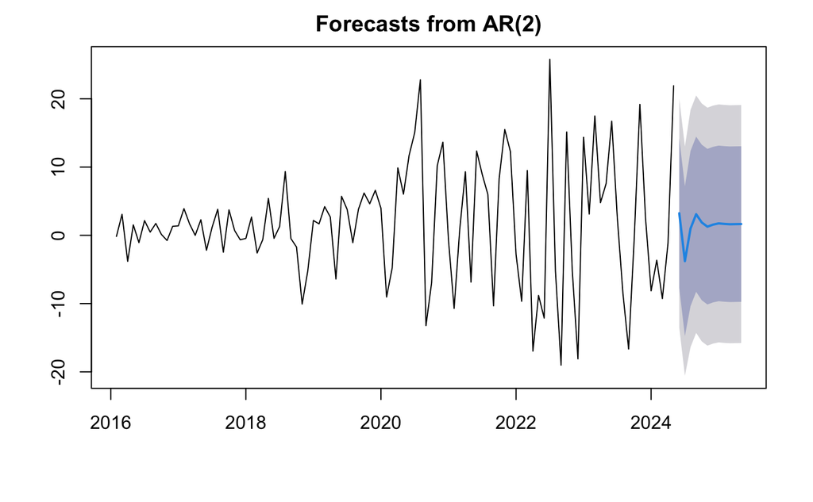

```r
# Forecasting with the AR model
ar_forecast <- forecast(ar_model, h=12)
plot(ar_forecast, main="Forecasts from AR(2)")
```

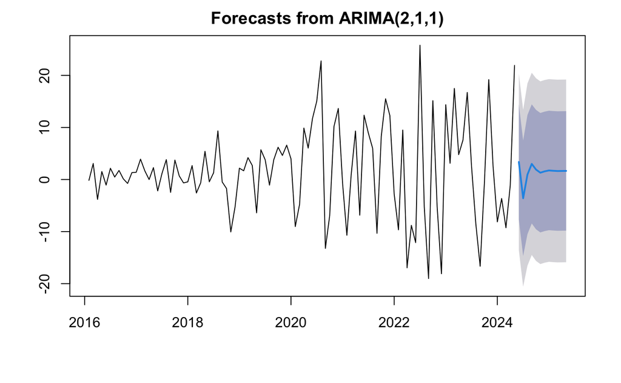

```r
# Forecasting with the SARIMA model
arma2_forecast <- forecast(arma_model2, h=12)
plot(arma2_forecast, main="Forecasts from ARIMA(2,1,1)")
```

#### GARCH Models

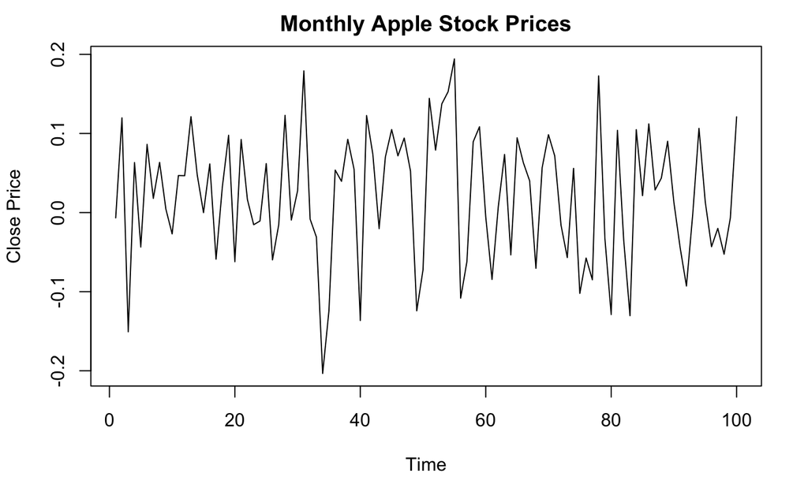

```r
# Create a time series object
aaplmonthly_ts2 <- ts(aapl_monthly_data$Close, start=c(2016, 01), end = c(2024, 05), frequency=12)
# Calculate returns for modeling
returns <- diff(log(aaplmonthly_ts2))
returns <- returns[!is.na(returns)]
plot(returns, main="Monthly Apple Stock Prices", ylab="Close Price", xlab="Time", type="l")
```

```r
# Display the fit summary
fit_garch
```

[output not shown]

```
*---------------------------------*
*          GARCH Model Fit        *
*---------------------------------*

Conditional Variance Dynamics
-----------------------------------
GARCH Model : sGARCH(1,1)
Mean Model  : ARFIMA(1,0,0)
Distribution    : norm

Optimal Parameters
------------------------------------
        Estimate  Std. Error  t value Pr(>|t|)
mu      0.020696    0.008198  2.52440  0.01159
ar1     0.009283    0.100840  0.09206  0.92665
omega   0.000212    0.000204  1.03801  0.29927
alpha1  0.000000    0.014482  0.00000  1.00000
beta1   0.969597    0.051349 18.88262  0.00000

Robust Standard Errors:
        Estimate  Std. Error   t value Pr(>|t|)
mu      0.020696    0.006649  3.112732 0.001854
ar1     0.009283    0.103105  0.090038 0.928257
omega   0.000212    0.000379  0.558168 0.576730
alpha1  0.000000    0.005313  0.000000 1.000000
beta1   0.969597    0.059723 16.234816 0.000000

LogLikelihood : 108.877

Information Criteria
------------------------------------

Akaike       -2.0775
Bayes        -1.9473
Shibata      -2.0822
Hannan-Quinn -2.0248

Weighted Ljung-Box Test on Standardized Residuals
------------------------------------
                        statistic p-value
```

[output cut: 22 more lines]

```
------------------------------------
Joint Statistic:  1.4525
Individual Statistics:
mu     0.07109
ar1    0.14752
omega  0.14307
alpha1 0.12991
beta1  0.14386

Asymptotic Critical Values (10% 5% 1%)
Joint Statistic:         1.28 1.47 1.88
Individual Statistic:    0.35 0.47 0.75

Sign Bias Test
------------------------------------
```

|  | t-value | prob | sig |
| --- | --- | --- | --- |
| Sign Bias | 0.04934009 | 0.9607519 |  |
| Negative Sign Bias | 0.84585590 | 0.3997586 |  |
| Positive Sign Bias | 0.20106034 | 0.8410812 |  |
| Joint Effect | 0.99589864 | 0.8022444 |  |

```
Adjusted Pearson Goodness-of-Fit Test:
------------------------------------
  group statistic p-value(g-1)
1    20      20.4       0.3709
2    30      21.8       0.8284
3    40      34.4       0.6796
4    50      42.0       0.7504


Elapsed time : 0.05360389
```

```r
# Plot diagnostics
plot(fit_garch)
```

```
Make a plot selection (or 0 to exit):

 1:   Series with 2 Conditional SD Superimposed     2:   Series with 1% VaR Limits
 3:   Conditional SD (vs |returns|)                 4:   ACF of Observations
 5:   ACF of Squared Observations                   6:   ACF of Absolute Observations
 7:   Cross Correlation                             8:   Empirical Density of Standardized Residuals
 9:   QQ-Plot of Standardized Residuals            10:   ACF of Standardized Residuals
11:   ACF of Squared Standardized Residuals        12:   News-Impact Curve
```

```r
1
```

[output not shown]

```
please wait...calculating quantiles...
```

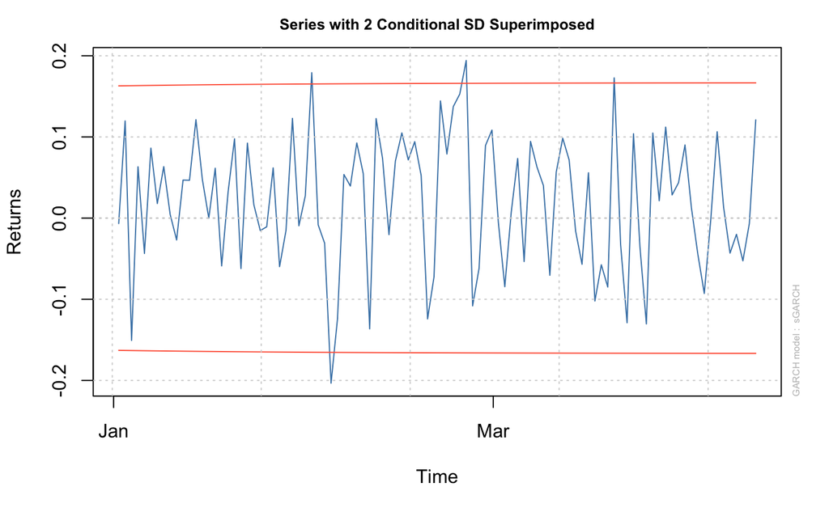

[output not shown]

```r
2
```

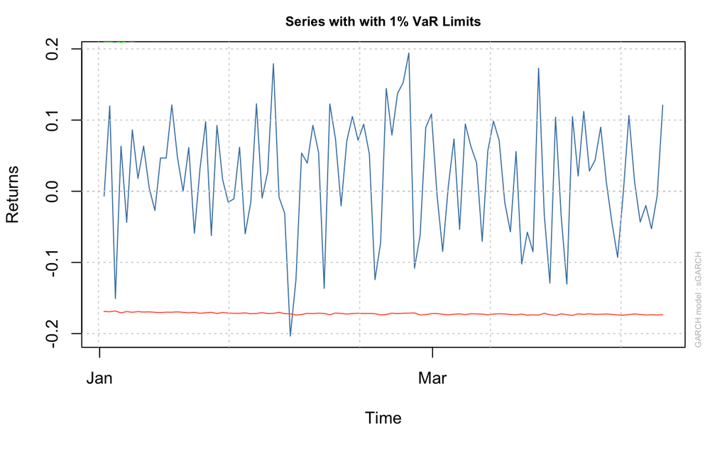

[output not shown]

```r
3
```

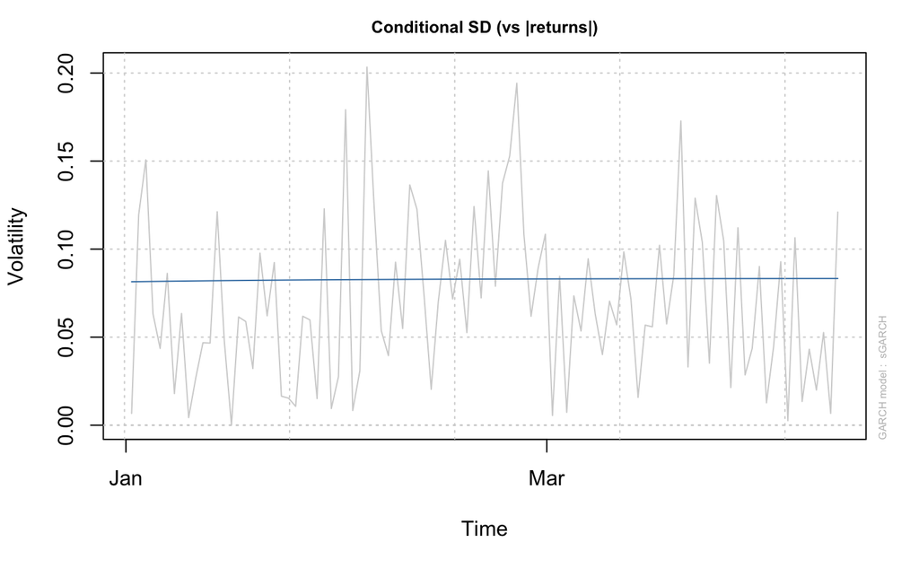

[output not shown]

```r
4
```

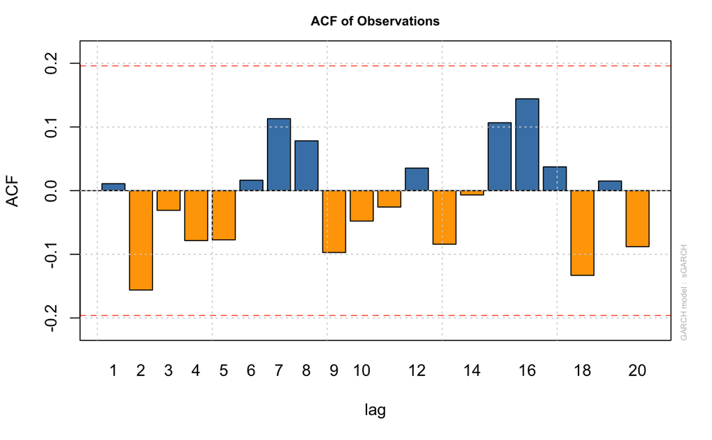

[output not shown]

```r
5
```

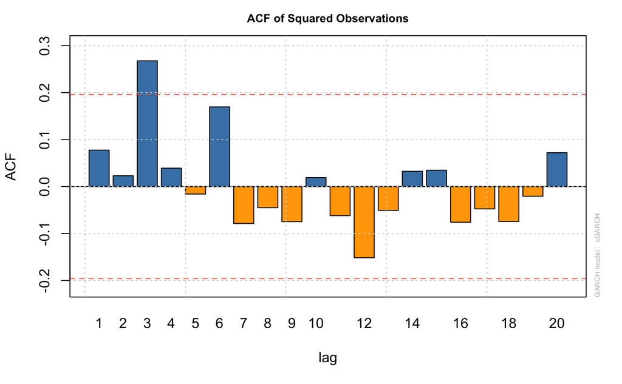

[output not shown]

```r
6
```

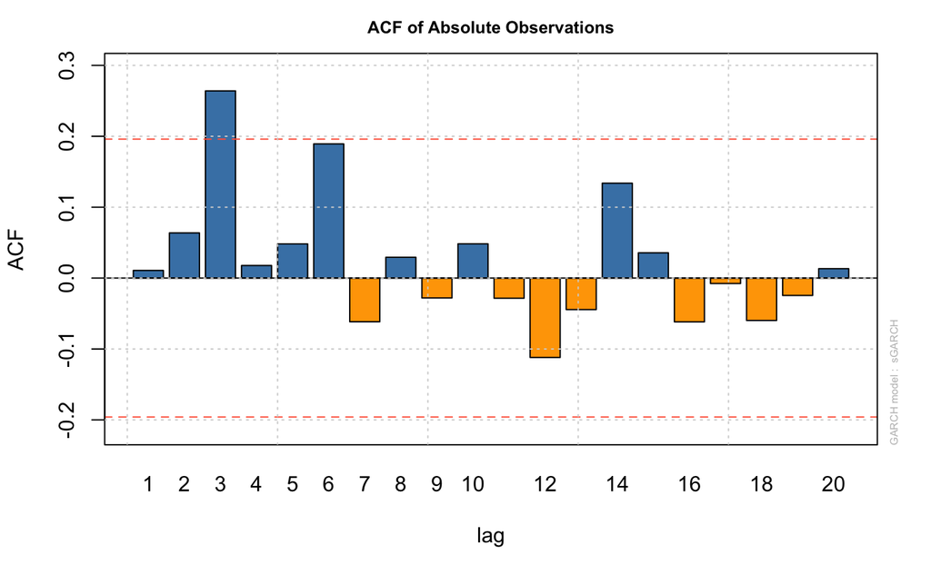

[output not shown]

```r
7
```

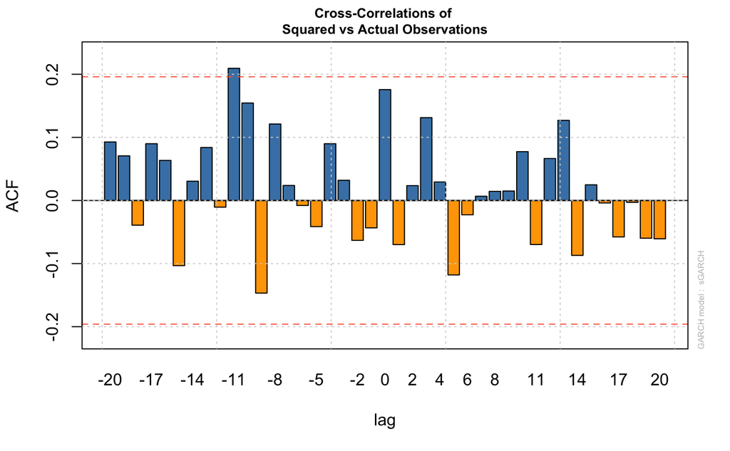

[output not shown]

```r
8
```

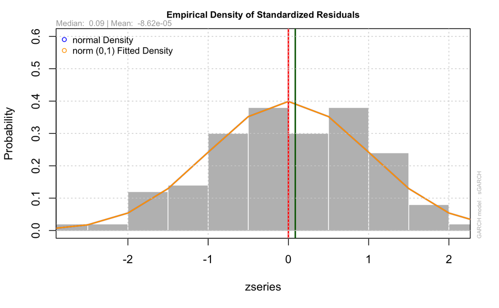

[output not shown]

```r
9
```

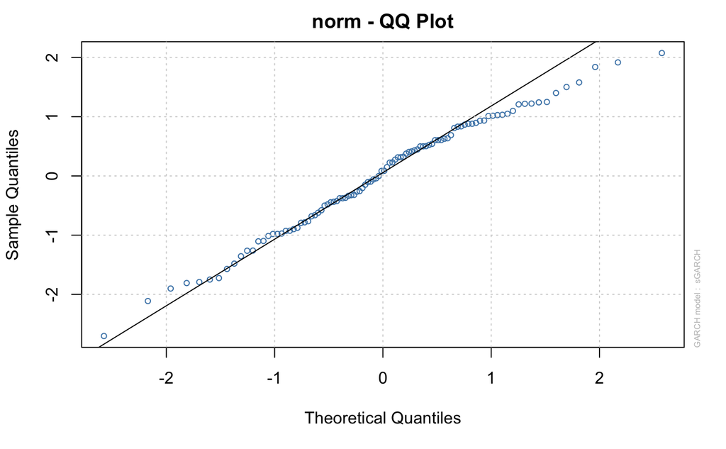

[output not shown]

```r
10
```

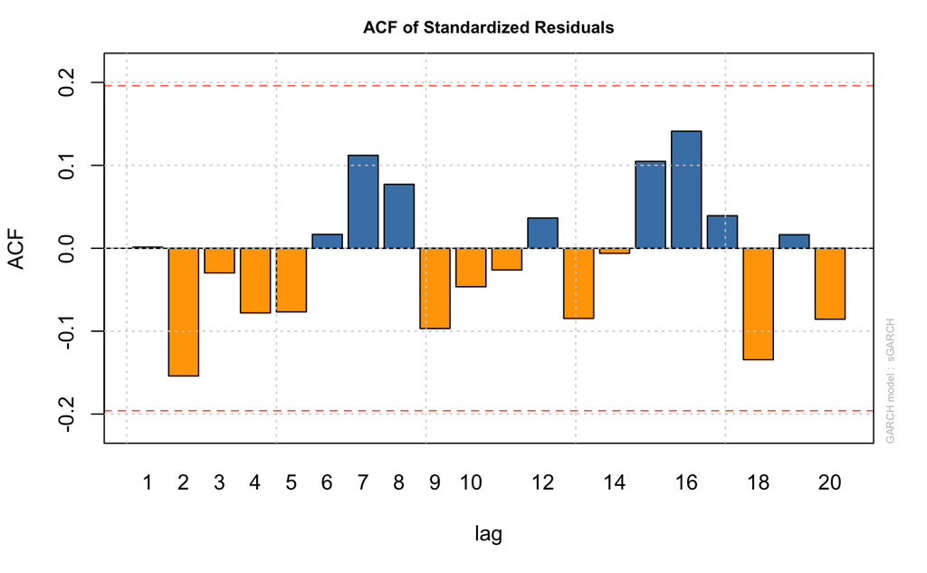

[output not shown]

```r
11
```

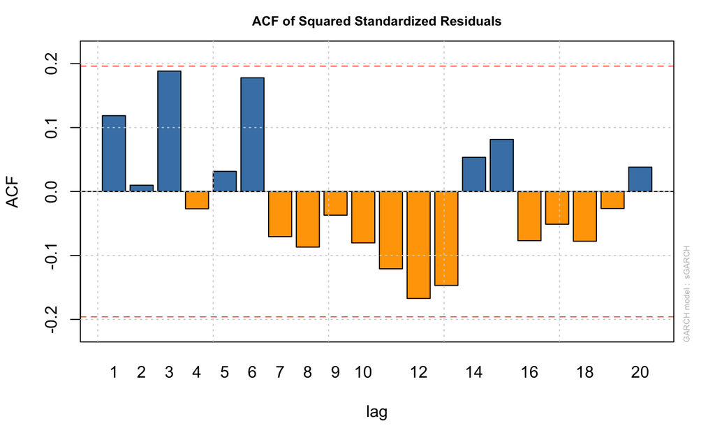

[output not shown]

```r
12
```

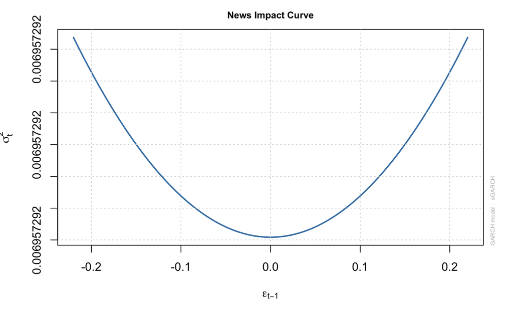

```r
0
```

#### Forecasting

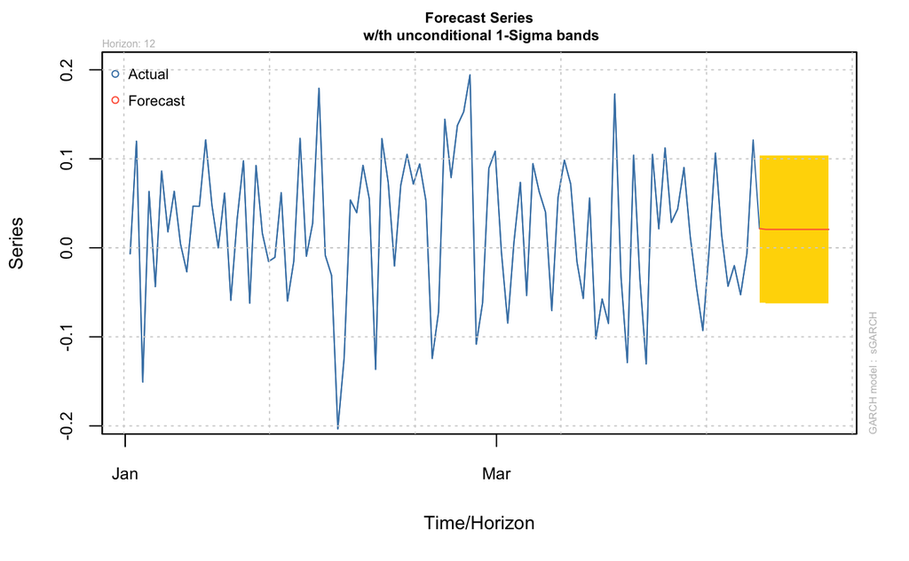

```r
# Forecasting with the TGARCH model
forecast_garch <- ugarchforecast(fit_garch, n.ahead=12)
plot(forecast_garch, which=1)  # Forecast series
```

#### Model Comparison

```r
# Comparing Models using AIC and BIC
models <- list(ar_model, ma_model, arma_model1, arma_model2)
model_names <- c("AR", "MA", "ARIMA(1,1,1)", "ARIMA(2,1,1)", "GARCH")

aic_values <- c(sapply(models, AIC), -2.0775)
bic_values <- c(sapply(models, BIC), -1.9473)

comparison <- data.frame(Model=model_names, AIC=aic_values, BIC=bic_values)
print(comparison)
```

[output not shown]